# Relatório da Escala de Crenças e Práticas

Guilherme e Jéssica

13-11-2014

# 1 Introduçao

Este relatório objetiva apresentar as análises exploratória do instrumento ``Escala de práticas na prevenção do uso de álcool e outras drogas’’, que está em fase de desenvolvimento pelo [Centro de Referência em Pesquisa, Intervenção e Avaliação em Álcool e Outras Drogas](http://www.ufjf.br/crepeia/).

O instrumento está sendo validado para população de educadores. O objetivo da pesquisa é oferecer uma medida confiável para avaliação das práticas profissionais de educadores de um curso à distância oferecido pela Secretaria Nacional de Políticas sobre Drogas para aproximadamente 10.000 educadores dos estados de Minas Gerais e Rio de Janeiro.

Durante todo o processo de desenvolvimento, foram utilizadas ferramentas de código-aberto, para facilitar o re-uso das técnicas e procedimentos desenvolvidos. Todo conteúdo do instrumento e de suas etapas estará disponível para o público no repositório (http://github.com/crepeia/ead-senad). Atualmente, o projeto está hospedado no repositório (http://github.com/henriquepgomide/ead-senad).

Neste relatório são apresentadas, análises da escala com base em uma amostra de 3064 educadores do curso. As análises foram conduzidas através da linguagem de programação R usando os pacotes *car* e *psych*.

## 1.1 Banco de Dados

O banco de dados da pesquisa, pode ser obtido no seguinte endereço: (https://github.com/henriquepgomide/ead-senad/blob/master/praticasprofissionais_df.csv).

## 1.2 Resultados

Os resultados são apresentados por tópicos: caracterização da amostra, avaliação descritiva da escala e análise fatorial exploratória.

### 1.2.1 Bibliotecas

```r
library(car) # Function Recode
library(psych) # Function Describe
library(mirt)  #Function bfactor
```

```r
library(ggplot2) # Fancy Charts
## Import dataframe
praticasPro  <- read.csv("praticasprofissionais_df.csv")
## Sum scales to remove NA's
praticasPro$scaleSum  <- rowSums(praticasPro[,32:68])
## Subset completed observations and consented participation
praticasPro  <- subset(praticasPro, subset=praticasPro$termo=="Sim" & praticasPro$estado=="Finalizadas" & !is.na(praticasPro$scaleSum))
```

### 1.2.2 Sócio-demográficas

#### 1.2.2.1 Idade

```r
## Age
### Clean data
praticasPro$idade  <- as.numeric(as.character(praticasPro$idade))
praticasPro$idade[praticasPro$idade < 18 | praticasPro$idade > 68 ]  <- NA
### Descriptives
summary(praticasPro$idade) # all
```

```
##    Min. 1st Qu.  Median    Mean 3rd Qu.    Max.    NA's
##    19.0    34.0    41.0    40.8    47.0    68.0     332
```

```r
by(praticasPro$idade, praticasPro$sexo, describe) #by sex
```

```
## praticasPro$sexo: Feminino
##   vars    n  mean   sd median trimmed   mad min max range skew kurtosis
## 1    1 2335 40.86 8.76     41   40.77 10.38  19  68    49 0.08    -0.64
##     se
## 1 0.18
## --------------------------------------------------------
## praticasPro$sexo: Masculino
##   vars   n  mean   sd median trimmed   mad min max range skew kurtosis  se
## 1    1 396 40.12 9.95     40   39.64 10.38  21  67    46 0.38    -0.59 0.5
```

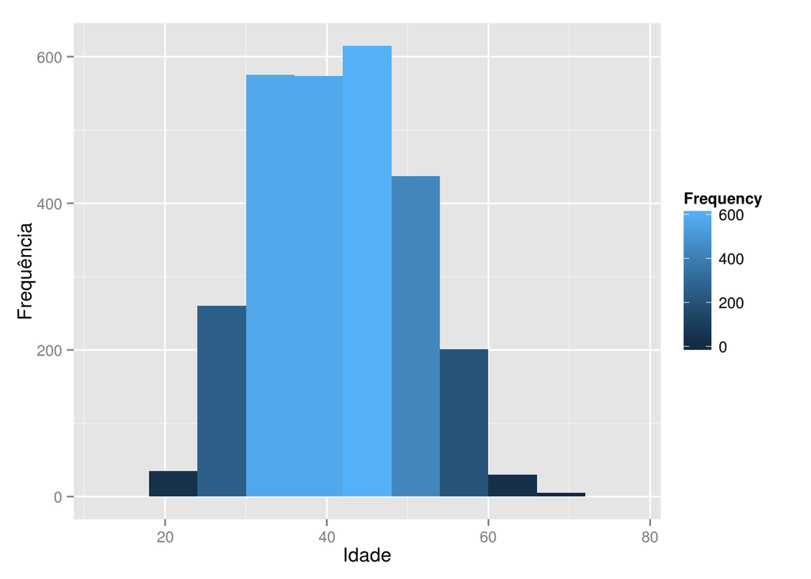

```r
ggplot(praticasPro, aes(x=idade)) + geom_histogram(aes(fill = ..count..), binwidth = 6) + xlab("Idade") + ylab("Frequência") + scale_fill_continuous(name="Frequency")
```